## Peer Grader Guidance

Please review the student expectations for peer review grading and peer review comments. Overall, we ask that you score with accuracy. When grading your peers, you will not only learn how to improve your future homework submissions but you will also gain deeper understanding of the concepts in the assignments. When assigning scores, consider the responses to the questions given your understanding of the problem and using the solutions as a guide. Moreover, please give partial credit for a concerted effort, but also be thorough. **Add comments to your review, particularly when deducting points, to explain why the student missed the points.** Ensure your comments are specific to questions and the student responses in the assignment.

# Background

The provided dataset is a subset of the public data from the 2022 EPA Automotive Trends Report. It will be used to study the effects of various vehicle characteristics on CO2 emissions.

## Data Description

The dataset consists of a dataframe with 2060 observations with the following 7 variables:

1. Model.Year: year the vehicle model was produced (quantitative)
2. Type: vehicle type (qualitative)
3. MPG: miles per gallon of fuel (quantitative)
4. Weight: vehicle weight in lbs (quantitative)
5. Horsepower: vehicle horsepower in HP (quantitative)
6. Acceleration: acceleration time (from 0 to 60 mph) in seconds (quantitative)
7. CO2: carbon dioxide emissions in g/mi (response variable)

## Instructions on reading the data

To read the data in `R`, save the file in your working directory (make sure you have changed the directory if different from the R working directory) and read the data using the `R` function `read.csv()`

```r
# load in libraries for the rest of assignment
library(ggplot2)
library(car)
library(dplyr)
# reading the dataset
data <- read.csv("vehicle_CO2_emis.csv")
head(data,3)
```

```
##   Model.Year Type Weight Horsepower Acceleration      MPG      CO2
## 1       1995  SUV   3500         94      13.2003 20.99489 423.2935
## 2       1996  SUV   3500        130      11.1597 20.29168 437.9628
## 3       1997  SUV   3500        130      11.7893 18.92057 469.7003
```

# Question 1: Exploratory Data Analysis [15 points]

1. **3 pts** Compute the correlation coefficient for each quantitative predicting variable (Model.Year, MPG, Weight, Horsepower, Acceleration) against the response (CO2). Describe the strength and direction of the top 3 predicting variables that have the strongest linear relationships with the response.

```r
# Calculate each of the corr. coefficients
new_correlation = "test"
#define the scope of new cor
correlations <- cor(data[,c("Model.Year", "MPG", "Weight", "Horsepower", "Acceleration", "CO2")])
#check for CO2
cor_CO2 <- correlations[,"CO2"]
cor_co2_test = 0
#define order
cor_CO2 <- cor_CO2[order(abs(cor_CO2), decreasing = TRUE)]
check_order_co2 = cor_co2_test+1
#return
cor_CO2
```

```
##          CO2          MPG       Weight   Model.Year Acceleration   Horsepower
##  1.000000000 -0.959831720  0.516333161 -0.479496864  0.311795475  0.007126864
```

```r
# Output the top 3 strongest
top_3_cors <- cor_CO2[2:4]
#return
top_3_cors
```

```
##        MPG     Weight Model.Year
## -0.9598317  0.5163332 -0.4794969
```

**Q1a ANSWER:** MPG: The correlation coefficient between MPG and CO2 is -0.9598317. This tells us there’s a very strong negative relationship between these two variables. In simpler terms, the more miles per gallon a vehicle gets, the less CO2 it emits.

Weight: The correlation coefficient between Weight and CO2 is 0.5163332. This indicates a moderate positive relationship. So, as the weight of the vehicle goes up, the CO2 emissions also increase.

Model.Year: The correlation coefficient between Model.Year and CO2 is -0.4794969. This shows a moderate negative relationship. Essentially, newer vehicle models tend to emit less CO2.

2. **3 pts** Create a boxplot of the qualitative predicting variable (Type) versus the response (CO2). Explain the relationship between the two variables.

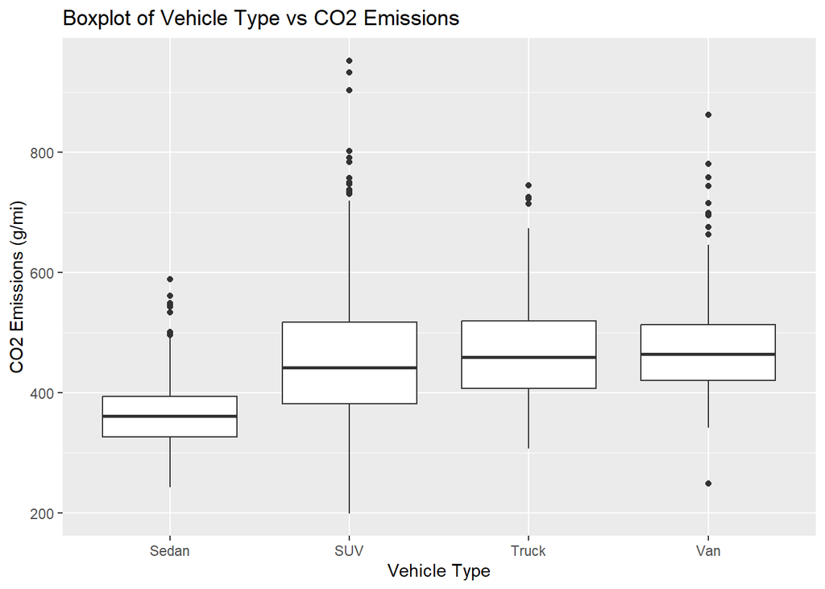

```r
# Create a boxplot for data
ggplot(data,aes(x = Type,y = CO2))+geom_boxplot()+ labs(title = "Boxplot of Vehicle Type vs CO2 Emissions",x = "Vehicle Type",y = "CO2 Emissions (g/mi)")
```

Sedan: Sedans generally have the lowest CO2 emissions among all the vehicle types. Their median CO2 emission is lower compared to SUVs, trucks, and vans. Plus, there are fewer outliers, which means most sedans have similar CO2 emission levels.

SUV: SUVs tend to emit more CO2 than sedans, with a higher median value. There’s also a wider range of CO2 emissions among SUVs, indicating more variability. Some SUVs have particularly high emissions, showing that they’re less efficient.

3. **6 pts** Create scatterplots of the response (CO2) against each quantitative predicting variable (Model.Year, MPG, Weight, Horsepower, Acceleration). Describe the general trend of each plot.

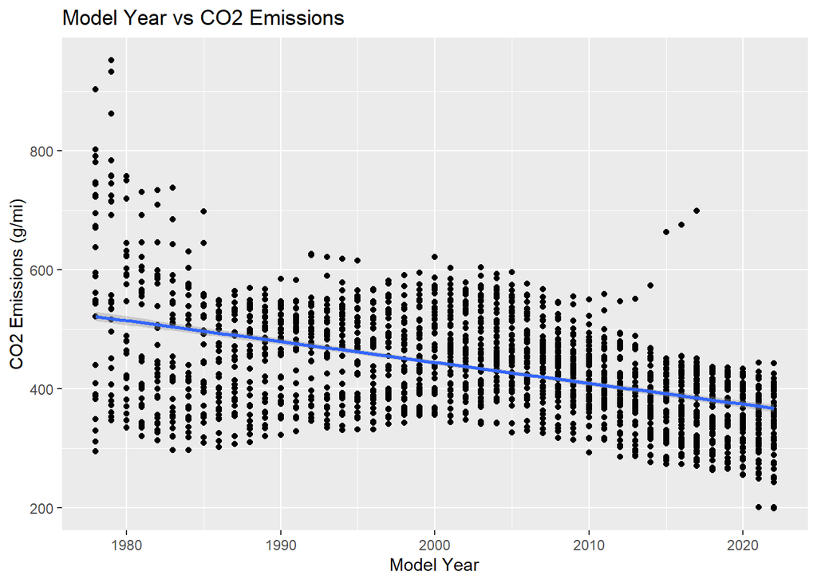

```r
# Scatterplot of Model.Year vs CO2
ggplot(data,aes(x= Model.Year,y= CO2)) +geom_point() +geom_smooth(method = "lm") +labs(title = "Model Year vs CO2 Emissions",x = "Model Year",y = "CO2 Emissions (g/mi)")
```

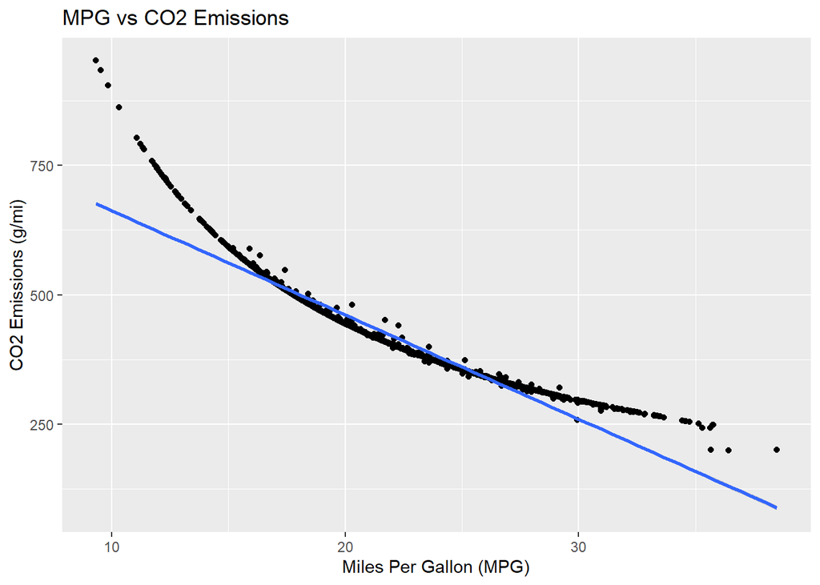

```r
# Scatterplot for MPG vs CO2
ggplot(data,aes(x= MPG, y= CO2)) +geom_point() +geom_smooth(method ="lm") +labs(title = "MPG vs CO2 Emissions",x ="Miles Per Gallon (MPG)",y ="CO2 Emissions (g/mi)")
```

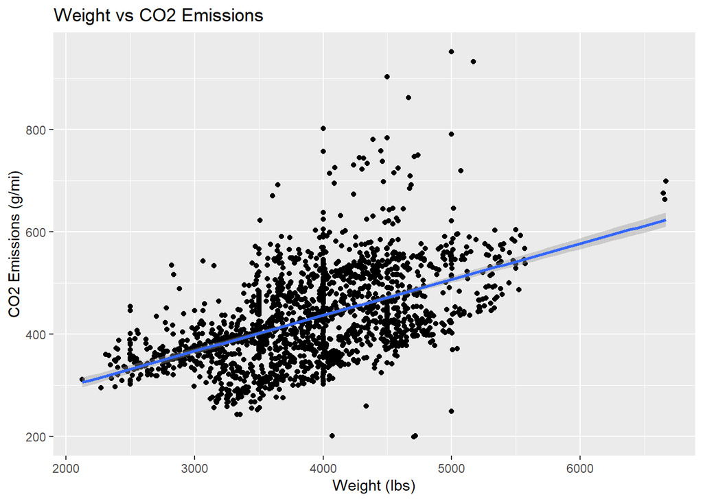

```r
# Scatterplot for Weight vs CO2
ggplot(data,aes(x = Weight, y = CO2)) +geom_point() +geom_smooth(method = "lm") +labs(title = "Weight vs CO2 Emissions",x = "Weight (lbs)",y = "CO2 Emissions (g/mi)")
```

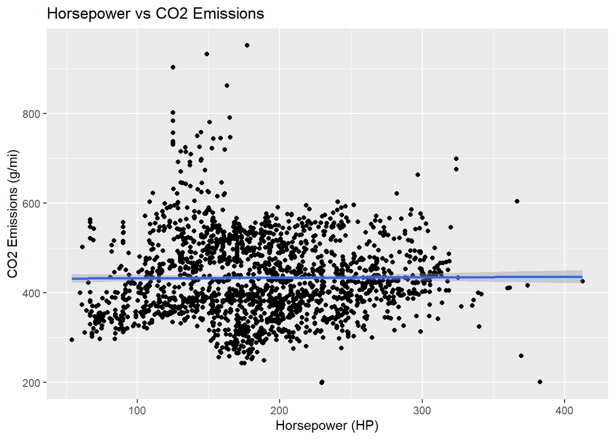

```r
# Scatterplot for Horsepower vs CO2
ggplot(data,aes(x =Horsepower,y =CO2))+geom_point() +geom_smooth(method = "lm") +labs(title ="Horsepower vs CO2 Emissions",x ="Horsepower (HP)",y ="CO2 Emissions (g/mi)")
```

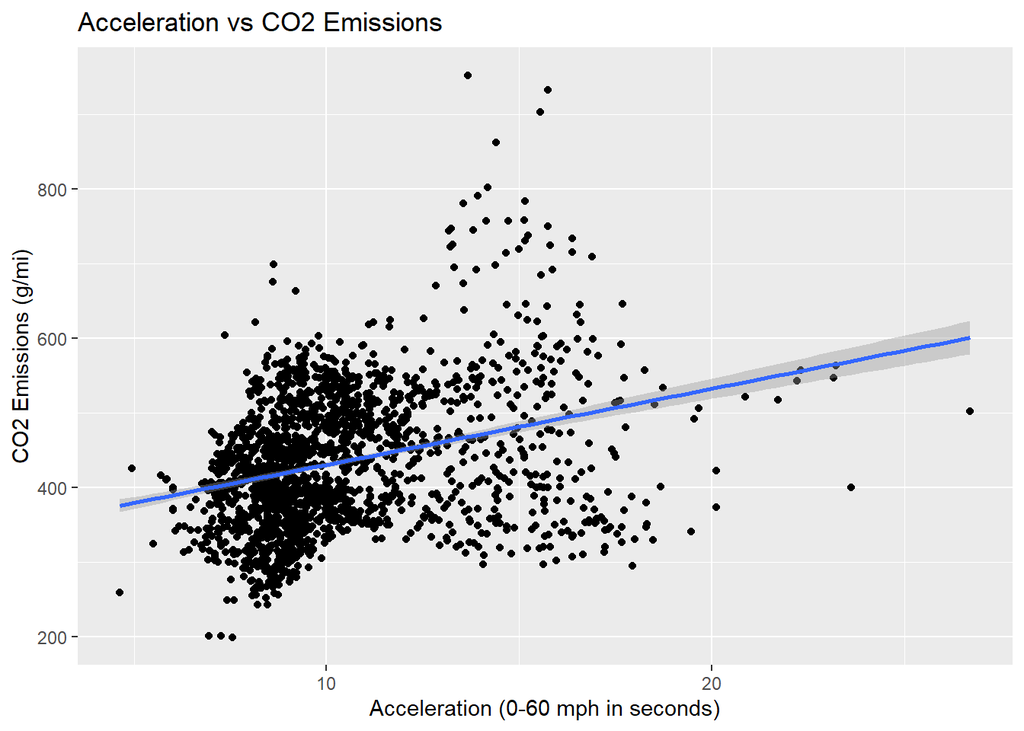

```r
# Scatterplot for Acceleration vs CO2
ggplot(data,aes(x = Acceleration,y = CO2)) +geom_point() +geom_smooth(method ="lm") +labs(title = "Acceleration vs CO2 Emissions",x ="Acceleration (0-60 mph in seconds)",y ="CO2 Emissions (g/mi)")
```

**Q1c ANSWER:** In the first plot, we can see that as the model year of the vehicles increases, the CO2 emissions tend to decrease. The downward sloping trend line indicates a negative linear relationship. This suggests that newer vehicle models generally emit less CO2 compared to older models, likely due to advancements in technology and stricter emission standards over time.

The second plot shows a strong negative nonlinear relationship between miles per gallon (MPG) and CO2 emissions. As MPG increases, CO2 emissions decrease significantly. This is because vehicles that are more fuel-efficient (higher MPG) produce fewer CO2 emissions. The trend line shows a steep decline, indicating a strong inverse relationship.

Looking at the third plot, there is a positive linear relationship between the weight of the vehicle and CO2 emissions. Heavier vehicles tend to emit more CO2. The trend line slopes upwards, showing that as the vehicle weight increases, CO2 emissions also increase. This makes sense since heavier vehicles require more energy to move, leading to higher fuel consumption and CO2 emissions.

The fourth plot shows a very weak linear relationship between horsepower and CO2 emissions. The trend line is almost flat, indicating that changes in horsepower do not significantly affect CO2 emissions. This suggests that other factors, such as weight and MPG, play a more significant role in determining a vehicle’s CO2 emissions.

Finally, in the fifth plot, we see a positive linear relationship between acceleration (time to accelerate from 0 to 60 mph) and CO2 emissions. As the time for acceleration increases, CO2 emissions also tend to increase. The trend line slopes upwards, indicating that vehicles with slower acceleration rates tend to emit more CO2, which might be due to less efficient engines or heavier vehicles that take longer to accelerate.

4. **3 pts** Based on this exploratory analysis, is it reasonable to fit a multiple linear regression model for the relationship between CO2 and the predicting variables? Explain how you determined the answer.

**Q1d ANSWER:** Based on the exploratory analysis, it seems reasonable to fit a multiple linear regression model for predicting CO2 emissions. The correlation analysis revealed strong or moderate linear relationships between CO2 and variables like MPG, Weight, and Model Year. Specifically, MPG has a very strong negative correlation, while Weight and Model Year have moderate positive and negative correlations with CO2, respectively.

Given these observations, fitting a multiple linear regression model makes sense as it can capture the combined effects of these predictors on CO2 emissions. This model will help us understand how each variable impacts CO2 emissions while controlling for the others. Thus, the identified predictors are well-suited for a multiple linear regression approach.